# Class 2 Supplemental Lab

Fall 2023

## Class 2 Supplemental Lab - Latitude & Longitude

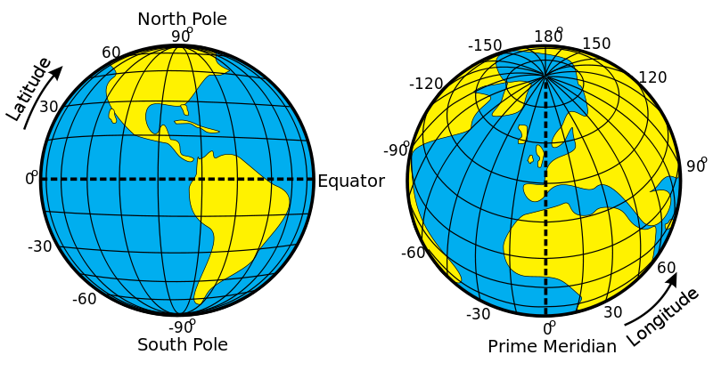

*source: Djexplo (Own work) [CC0], via Wikimedia Commons*

### Concepts & Themes:

This week’s lab will feature exploration of the following:

- [Latitude and Longitude](https://en.wikipedia.org/wiki/Geographic_coordinate_system)
- [Decimal Degree Precision](https://en.wikipedia.org/wiki/Decimal_degrees)
- Geocoding
- [Reverse Geocoding](https://en.wikipedia.org/wiki/Reverse_geocoding)
- [Differences between WGS EPSG:4326 - Pseudo-Mercator EPSG:3857](https://en.wikipedia.org/wiki/Web_Mercator)
- [Spatial vs. Attribute Data](http://www.whatisgis.com/whatisgis_data.htm)
- [Base Maps vs. Features](https://www.gislounge.com/basemaps-defined/)

### Link & Data Sources for Lab I, II & III:

During this week’s lab we will utilize the following online utilities, services and data sources:

### Lab I:

In this first lab, we will explore decimal precision in latitude and longitude (“lat long”) utilizing as our start ‘point’ high precision lat long. We will degrade that precision 5 times over and then map our results to see the critical role that decimal percision plays in coordinates and resulting points features in mapping.

- **Step 1**: Download [Data - Part I - Statue of Liberty](https://gist.github.com/gis-nspe-tns/62d629c7253013b78860951c83cba227). Once downloaded, unzip the folder and inside there will be located a `.csv` file for the Statue of Liberty with a precise lat long coordinate pair that represents the precise location of the statue. As discussed in the lecture, lat long pairings are a very common points feature format used in mapping, often displayed in a coordinate space atop a base map.
- **Step 2**: Use a text editor to open the Statue of Liberty `.csv` file - on a PC utilizing a default editor such as Notepad or [Notepad ++](https://notepad-plus-plus.org/); on a Mac OS X, [textedit](https://en.wikipedia.org/wiki/TextEdit). Once opened, `copy/paste` the row 5 times, resulting in a total 6 instances of the same row.

> Note: now is a good time to explore a robust text editor to employ during this course. Here are some [good options](https://lifehacker.com/five-best-text-editors-1564907215).
- **Step 3**: Starting with the bottom 6th row, remove the last digit from lat and long decimal numbers respectively. Continue up the `.csv` removing 1 more digit from lat and long until there are no digits after the decimal point in the second row under the original Statue of Liberty lat long. Save the results as `.txt` and then simply convert the file extension from `.txt` to `.csv`.
- **Step 4**: Navigate to [geojson.io](http://geojson.io/). At the left, toggle `open>file` and point to the `.csv` that has been edited for Statue of Liberty. `Import` this file. Once complete, we can see the effect of decimal point precision in lat long pairings. This lab illustrates the importance of understanding the following aspects of lat long data in tabular format:
  - The provenance of your data - where did it come from & how was it derived. Often high precision lat long will be derived from GPS units, while other sources of lat long may be less accurate.
  - The precision of the lat long pairings - is the data sufficiently precise to be of value for the scale of your mapping. For large-scale mapping, high precision is usually critical. For small-scale mapping, high precision lat long may not be required.

**Lab I Video Guide:**

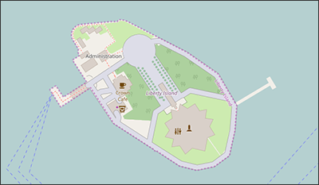

### Lab II:

- In the preceding lab, latitude and longitude were expressed in tabular columns as decimal numbers. In this way, ‘spatially aware’ utilities are able to translate the numbers onto the `WGS84` coordinate system.
  - What happens when latitude and longitude are not available as decimal numbers?
- One approach is to capture the ‘address’ of a location. Addresses have various levels of precision from highly precise ‘rooftop’ precision (123 Ash Drive, Anytown, Anystate, USA) to much less precise ‘city or town’ (Anytown, Anystate, USA). In the following lab, location is expressed in two columns - a city and its corresponding state. Using a **Geocode** process, these known ‘address’ locations will be transformed into coordinate locations upon the `WGS84` coordinate system. Once done, both X and Y coordinates can be recorded to the dataset attribute table within QGIS.
- In this **Lab II** process, we will also learn how to employ the following from within QGIS:
  - [Utilize the QGIS Plugin Architecture](http://www.qgistutorials.com/en/docs/using_plugins.html)
  - Install the [mmqgis plugin](https://plugins.qgis.org/plugins/mmqgis/)
  - Geocode from within QGIS using the *OpenStreetMap* services.
  - Add X,Y Coordinates via the [QGIS Field Calculator](https://docs.qgis.org/2.8/en/docs/user_manual/working_with_vector/field_calculator.html)
  - Export tabular results from QGIS using the [mmqgis plugin](https://plugins.qgis.org/plugins/mmqgis/)
- **Step 1**: Download [75 City & States Dataset](https://gist.github.com/gis-nspe-tns/b734b6586abf6ba207e7a818ee81a5d3). Once downloaded, unzip the folder and inside there will be located a `.csv` file for 75 US cities with their respective states:

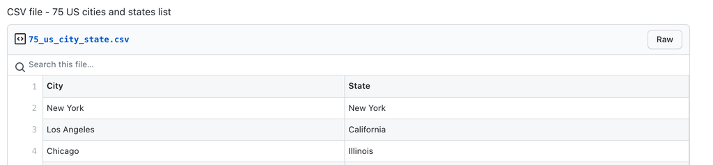

- After loading the 75 US cities dataset into QGIS utilizing `Delimited Text` as data source, save `.qgis` as `c2_l3.qgis`:

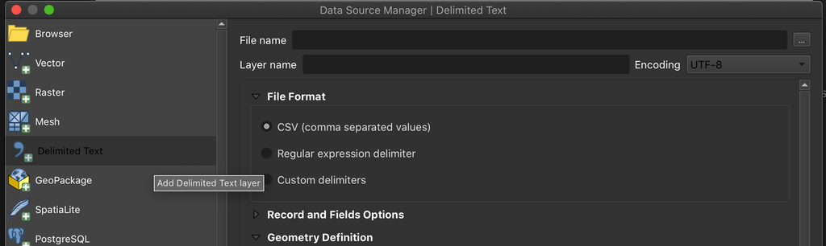

- **Step 2**: Install the [mmqgis plugin](https://plugins.qgis.org/plugins/mmqgis/), which will be utilized for both geocoding and exporting `.shp` attribute data as `.csv`
  - *Main Menu > Plugins > Manage and Install Plugins*:

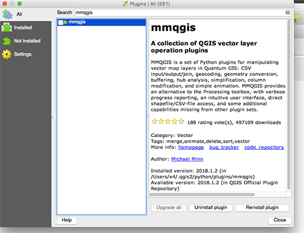

- **Step 3**: initiate the geocode process via the `mmqgis plugin> Geocode CSV with Google/OpenStreetMap`

[figure not shown]

- Add fields, using the following image as a guide. Be sure to choose `Web Service > OpenStreetMap/Nominatim`. Make sure to set the *input* and *output* directory locations within lab folder. Further, make sure to choose the correct columns for *City* and *State*. Since no other fields are available, those can be set to the default *(none)*. Finally, *click* **Apply** to run the geocode:

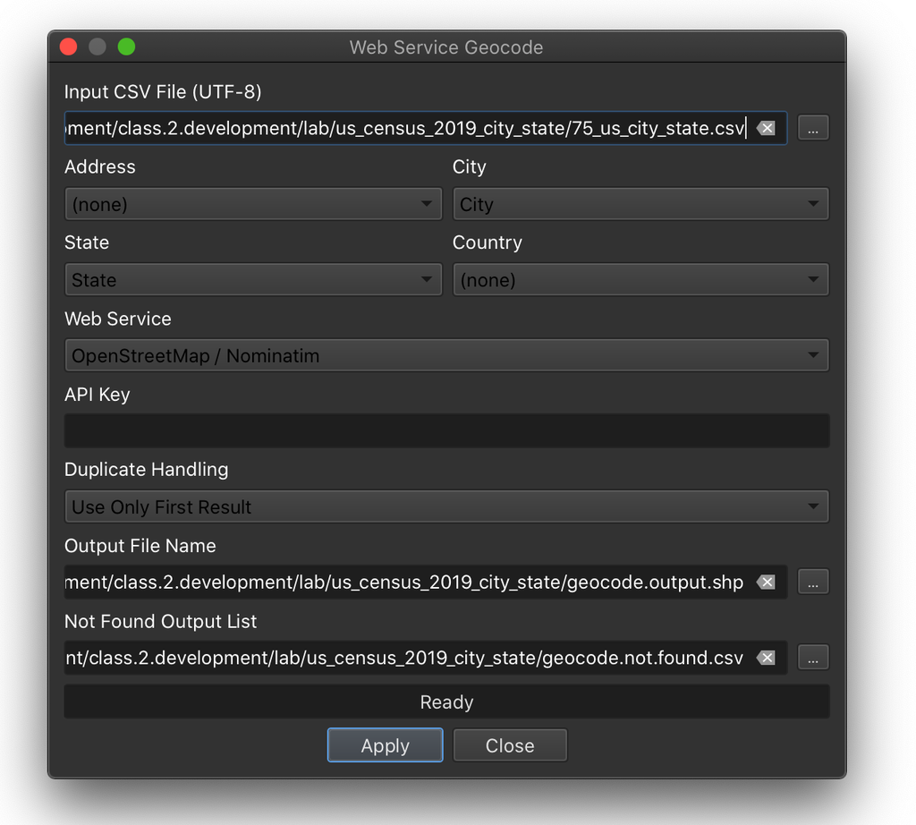

- Run the geocode, results should look similar to the following (*right-click > zoom to layer* to see the features in **Map Canvas**:

> Note: expect the geocode to take up to 10 minutes or so, especially if you are on a slow internet connection.

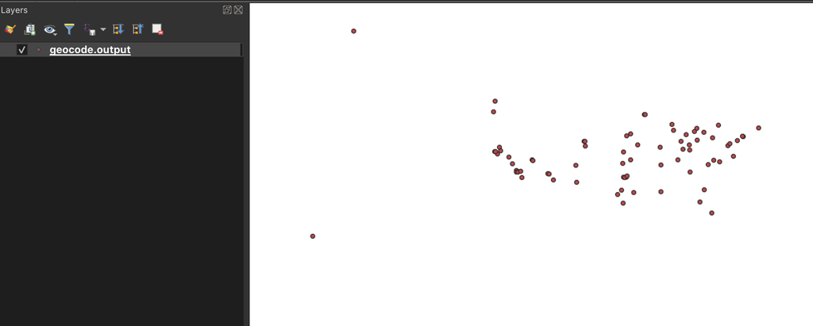

- **Step 4**: While the geocode produces `.shp` geometry that is accurate to the OpenStreetMap geocoding service, it doesn’t produce an x,y coordinate pair per se in the attribute table. Often this locational component is valuable for future mapping purposes. To do this final task, open `Field Calculator` which is just right of `Open Attribute Table` from the main toolbar:

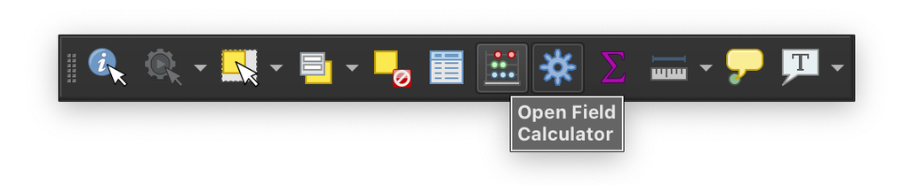

- Proceed to enact `Field calculator`
- For `Output field name` type `x_coord` first; on the second pass, type `y_coord`
- The `Output field type` will be decimal
- Keep default `Output field length`
- Choose `Geometry` at right drop-down section, and find `$x` and `$y`
- In the `Expression Editor` choose `$x` for `x_coord` and `$y` for the `y_coord` on the second pass.
- For `Precision`, make sure to choose just 1 because in this particular mapping instance we started with just city names which lacks a precision greater than ‘large city or district’. Make sure to review the chart from the [Wikipedia page for Decimal Degrees](https://en.wikipedia.org/wiki/Decimal_degrees), also shown below:

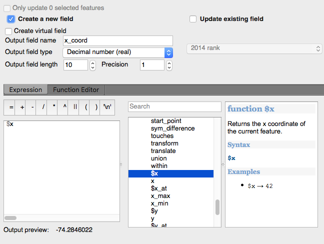

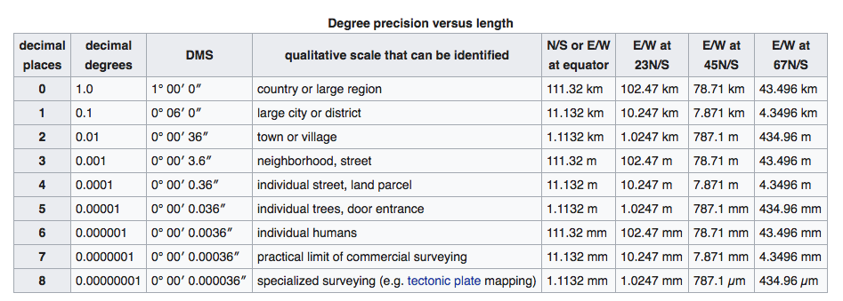

- Return to map. Turn off `Toggle Editing` via a *right-click > dropdown > Toogle Editing*:

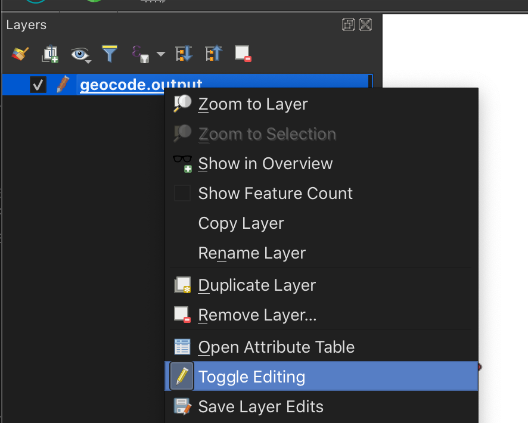

- Review the new `x_coord` and `y_coord` fields in the attribute table:

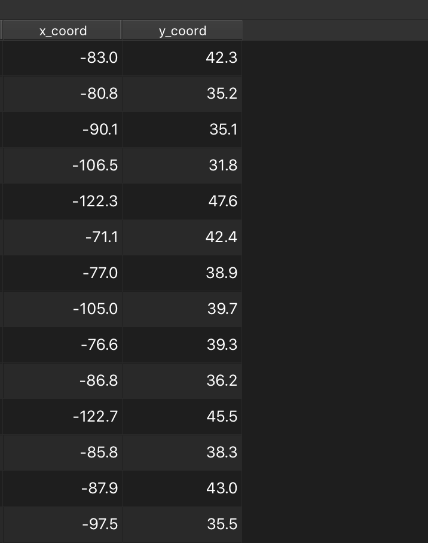

- **Step 5**: to export the resulting tabular data with the new x,y coordinates, utilize `mmqis` again as follows:

[figure not shown]

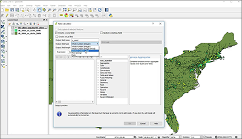

> Note: video guide utilizes *Google Maps Geocoding API* within QGIS 2.x, not the more recent QIS 3.x

### Lab III:

#### Precision, Scale & Output Length

[figure not shown]

*Precision :)*

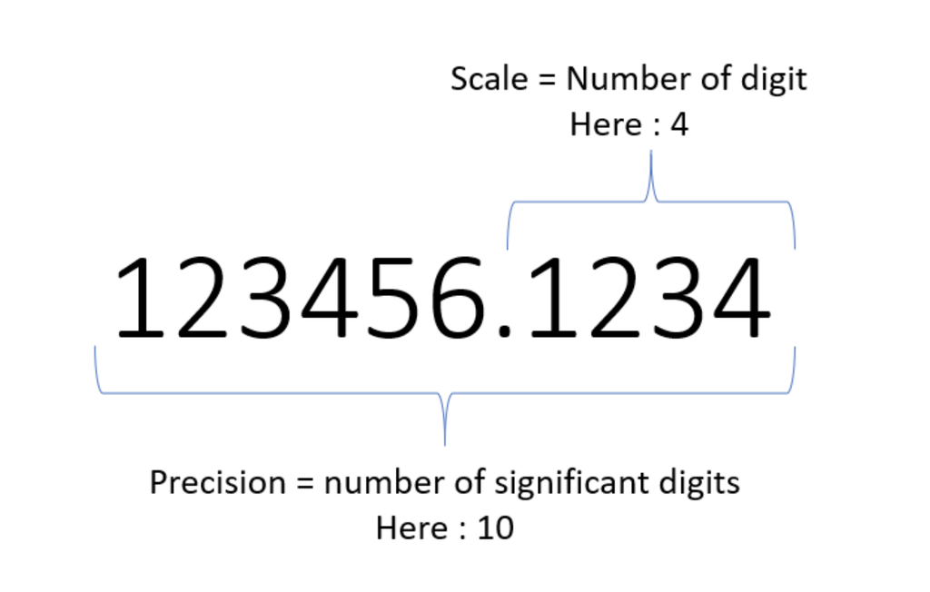

*Number Precision and Scale*

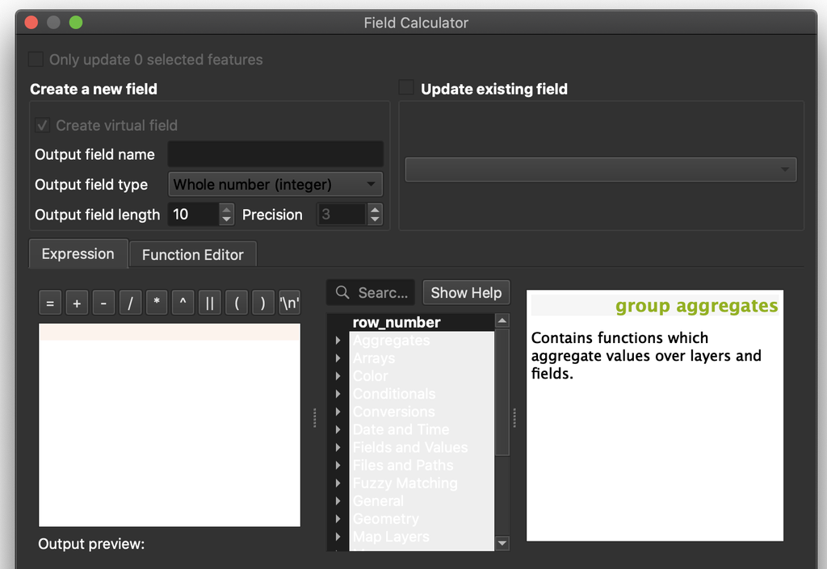

*QGIS Field Calculator*

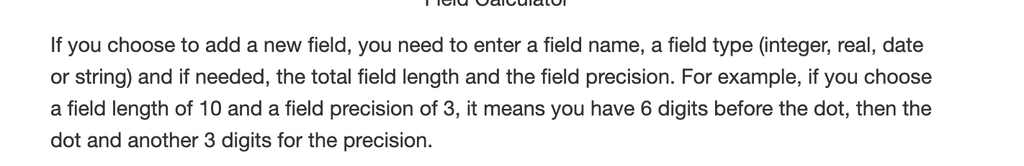

*Length and Precision in QGIS*

### Further References:

`.csv` overview:

- [`.csv`file format](https://en.wikipedia.org/wiki/Comma-separated_values) - contextual information for the `.csv` file format
- [`.csv` file creation](https://www.computerhope.com/issues/ch001356.htm) - how to create `.csv` formated datasets

- [US Census Geocoder](https://www.census.gov/geo/maps-data/data/geocoder.html) - single address or batch submit up to 10,000 addresses at a time
- [batchgeo](https://batchgeo.com/) - provides 250 free records
- [geocodio](https://geocod.io/) - provides 2,500 free records per day
- [Nasa Latitude/Longitude Finder](https://mynasadata.larc.nasa.gov/latitudelongitude-finder/) - 1 record entry
- [GOAT](http://a030-goat.nyc.gov/goat/Default.aspx) - The NYC geocoder - 1 record entry, high precision for NYC-specific addresses, streets and buildings